# Movie Recommendation Project

PK (Kasidit) Ratanavijai

9/5/2019

## Executive Summary

Moview recommendation system filter out the title that a particular user would be interested in or would buy based on his or her previous history. The more data available about a user the more accurate the recommendations.

The objective of this project is to create a recommender system based on variables of MovieLens dataset that minimizes the loss so that the RMSE is as small as possible.

The steps include Data preparation and Analysis, Methodology and various tools used in the process, Reporting, and Recommendation.

Finally, ~the recommender systems builted on this dataset are evaluated and choosen based on the RMSE - Root Mean Squared Error that should be at least lower than **0.87750**.~

$$\mbox{RMSE} = \sqrt{\frac{1}{n}\sum_{t=1}^{n}e_t^2}$$

~For accomplishing this goal, the **Regularized Movie+User+Genre Model** is capable to reach a RMSE of **0.8628**, that is really good.~

## Project objectives

Creating a movie recommendation system using the MovieLens dataset, which the entire latest MovieLens dataset can be found here (https://grouplens.org/datasets/movielens/latest/). We will use the 10M version of the MovieLens dataset to make the computation a little easier.

The version of movielens dataset used for this final assignment contains 10 Milions of movies ratings, partitioned into 9 Milions for training data set and 1 Milion for evaluate data set. Training set composed from 69,878 users with 9,000,061 rating from 0.5 to 5 and 10,677 different movie titles in 20 genres such as Action, Adventure, Horror, Drama, Thriller.

Then use a machine learning algorithm using the inputs in one subset to predict movie ratings in the validation set to train a movie recommendation system.

The goal is to build an algorithm that minimizes the loss so that the RMSE is as small as possible.

## Data Ingestion, preparation, and analysis

### Data Ingestion

The data set partitioned into 9 million obervations training data set for algorithm training and 1 million obervations test to final evaluate the algorithm.

**The training data set** contatins 69,878 users, 10,677 different movie titles, and 9,000,061 total ratings

| Users | Movies | Rating |
| --- | --- | --- |
| 69878 | 10677 | 9000061 |

**The testing data set** contatins 68,531 users, 9,796 different movie titles, and 999,993 total ratings

| Users | Movies | Rating |
| --- | --- | --- |
| 68531 | 9796 | 999993 |

**Header of the training data set**

| userId | movieId | rating | timestamp | title | genres |
| --- | --- | --- | --- | --- | --- |
| 1 | 122 | 5 | 838985046 | Boomerang (1992) | Comedy\|Romance |
| 1 | 185 | 5 | 838983525 | Net, The (1995) | Action\|Crime\|Thriller |
| 1 | 231 | 5 | 838983392 | Dumb & Dumber (1994) | Comedy |
| 1 | 292 | 5 | 838983421 | Outbreak (1995) | Action\|Drama\|Sci-Fi\|Thriller |
| 1 | 316 | 5 | 838983392 | Stargate (1994) | Action\|Adventure\|Sci-Fi |
| 1 | 329 | 5 | 838983392 | Star Trek: Generations (1994) | Action\|Adventure\|Drama\|Sci-Fi |

**Structure of the training data set**

- **userId** `<integer>` that contains the unique identification number for each user.
- **movieId** `<numeric>` that contains the unique identification number for each movie.
- **rating** `<numeric>` that contains the rating of one movie by one user. Ratings are made on a 5-Star scale with half-star increments.
- **timestamp** `<integer>` that contains the timestamp for one specific rating provided by one user.
- **title** `<character>` that contains the title of each movie including the year of the release.
- **genres** `<character>` that contains a list of pipe-separated of genre of each movie.

### Data preparation

Data preparation gone through these steps

1.Normalize the Genres column to single values by extract each genre from pipe value. 2.Convert numeric timestamp to date type including year movie release, year that movie was rated, and month that movie was rated.

**Normalize form**

| userId | movieId | rating | title | genre | release | yearOfRate | monthOfRate |
| --- | --- | --- | --- | --- | --- | --- | --- |
| 1 | 122 | 5 | Boomerang | Comedy | 1992 | 1996 | 8 |
| 1 | 122 | 5 | Boomerang | Romance | 1992 | 1996 | 8 |
| 1 | 185 | 5 | Net, The | Action | 1995 | 1996 | 8 |
| 1 | 185 | 5 | Net, The | Crime | 1995 | 1996 | 8 |
| 1 | 185 | 5 | Net, The | Thriller | 1995 | 1996 | 8 |
| 1 | 231 | 5 | Dumb & Dumber | Comedy | 1994 | 1996 | 8 |

### Data Analysis

#### Genre Analysis

**Rating distribution over Genre**

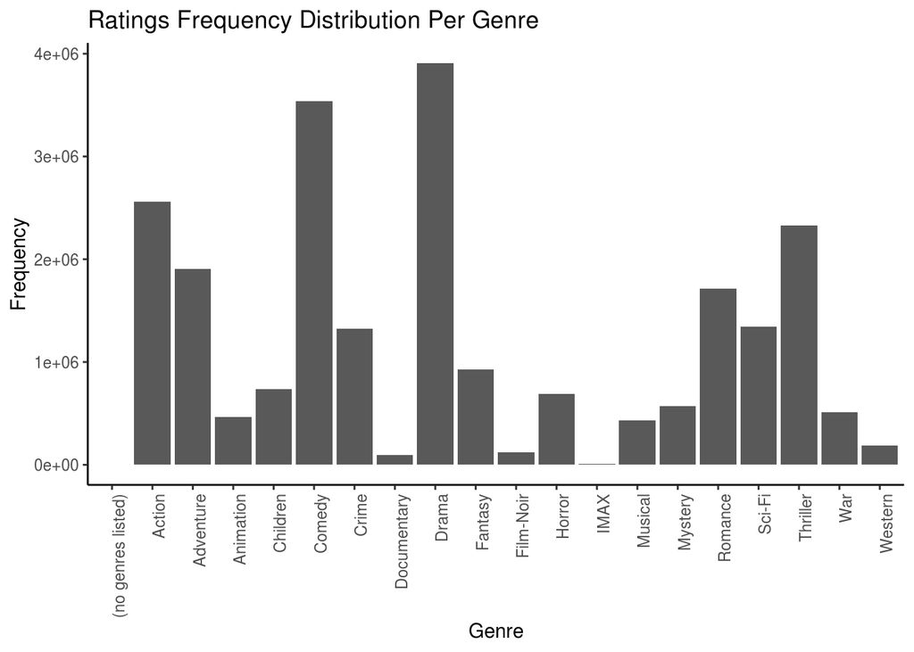

Notice that there are huge different in number of ratings received between each genres.

**Mean Distribution per Genre**

However, We see not much different in mean rating for each genre.

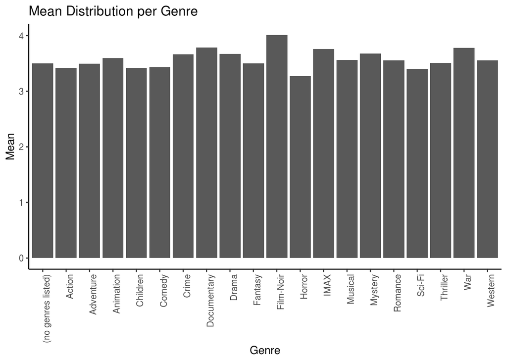

Here is ranking of genre by ratings.

| genre | mean |
| --- | --- |
| Film-Noir | 4.011732 |
| Documentary | 3.784385 |
| War | 3.779457 |
| IMAX | 3.761844 |
| Mystery | 3.677412 |
| Drama | 3.673047 |
| Crime | 3.666151 |
| Animation | 3.599588 |
| Musical | 3.562761 |
| Western | 3.555122 |
| Romance | 3.553594 |
| Thriller | 3.506879 |
| Fantasy | 3.502419 |
| (no genres listed) | 3.500000 |
| Adventure | 3.494076 |
| Comedy | 3.437040 |
| Action | 3.421589 |
| Children | 3.418673 |
| Sci-Fi | 3.396756 |
| Horror | 3.269523 |

#### Rating Analysis

**Rating frequency per title**

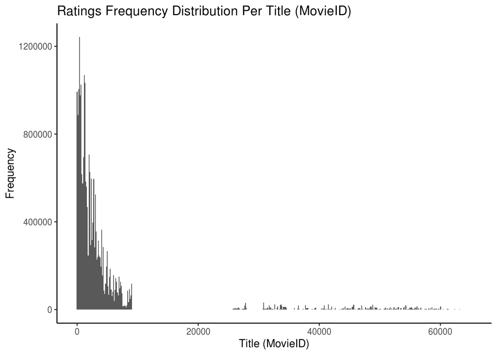

Notice from the distribution that some movies get rated more than other. This should not surprise given that there are blockbusters watched by millions and artsy independent movies watched by just a few.

**Rating frequency per user**

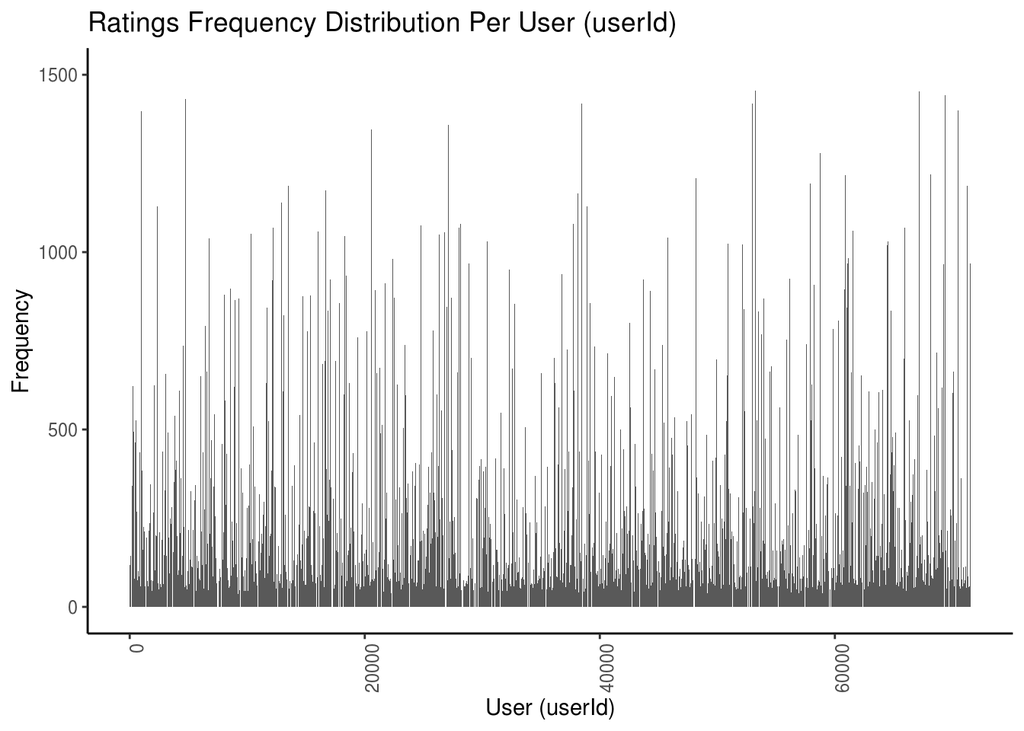

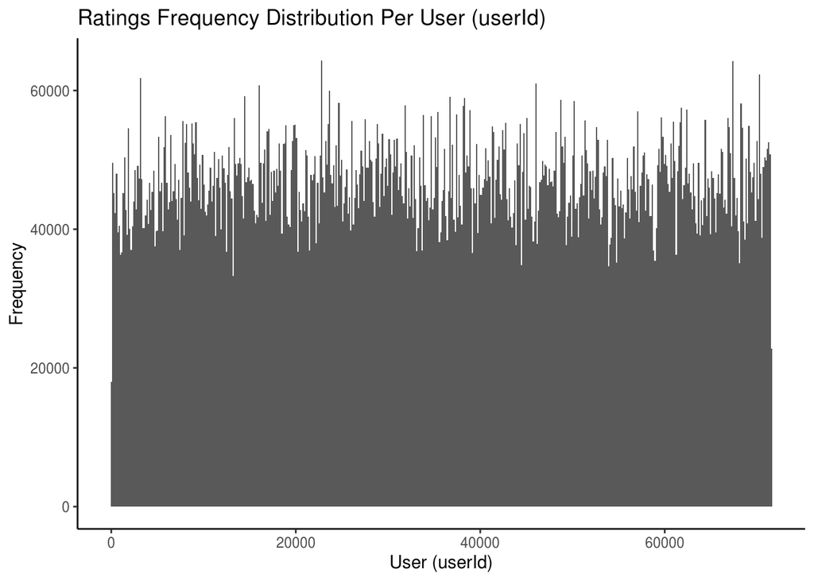

This plot shows that some users are more active than others at rating movies. Notice that some users have rated over 1,000 movies while others have only rated a handful.

**Rating Distribution**

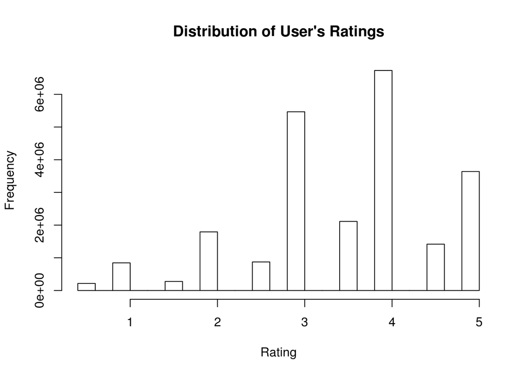

Observe that there are a small amount of under average rating (below 3). The user tends to give a vote if he liked the movie that less liked the movie. 1 and 2 ratings are less common than 4 and 5 ratings.

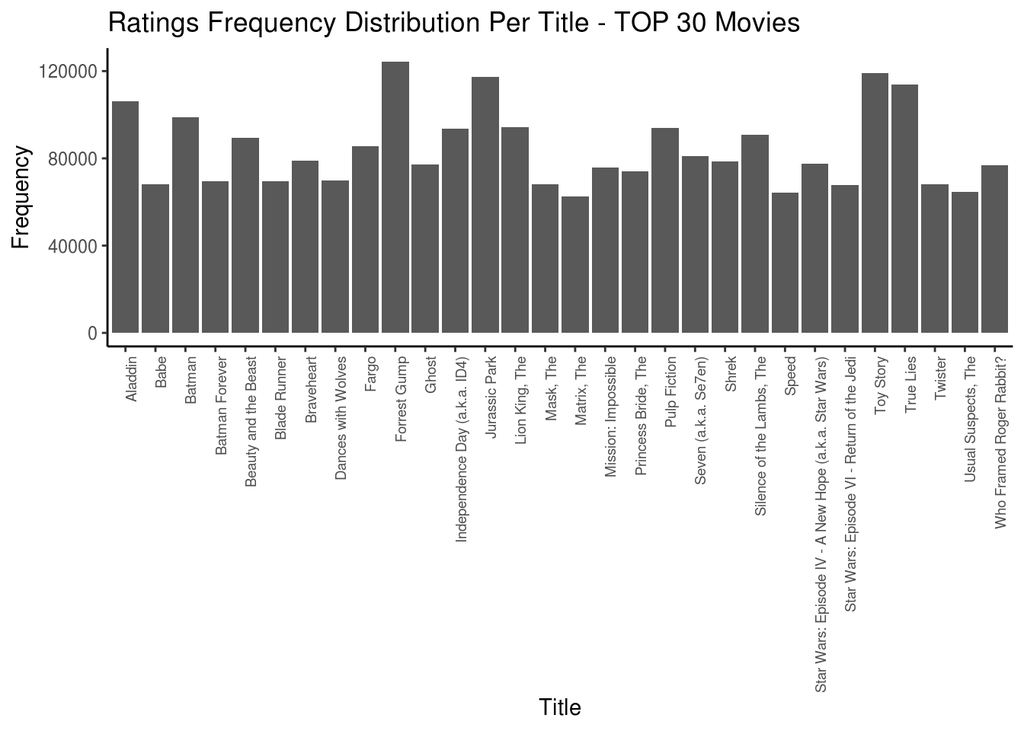

Here is title with the most ratings receive

| title | count |
| --- | --- |
| Forrest Gump | 124304 |
| Toy Story | 119130 |
| Jurassic Park | 117164 |
| True Lies | 113930 |
| Aladdin | 106070 |
| Batman | 98656 |
| Lion King, The | 94435 |
| Pulp Fiction | 94008 |
| Independence Day (a.k.a. ID4) | 93440 |
| Silence of the Lambs, The | 90840 |

**Top 20 titles with highest rating**

| title | mean |
| --- | --- |
| Blue Light, The (Das Blaue Licht) | 5.000000 |
| Constantine’s Sword | 5.000000 |
| Fighting Elegy (Kenka erejii) | 5.000000 |
| Hellhounds on My Trail | 5.000000 |
| Satan’s Tango (Sátántangó) | 5.000000 |
| Shadows of Forgotten Ancestors | 5.000000 |
| Sun Alley (Sonnenallee) | 5.000000 |
| Human Condition II, The (Ningen no joken II) | 4.833333 |
| Human Condition III, The (Ningen no joken III) | 4.750000 |
| Who’s Singin’ Over There? (a.k.a. Who Sings Over There) (Ko to tamo peva) | 4.750000 |
| Class, The (Entre les Murs) | 4.666667 |
| I’m Starting From Three (Ricomincio da Tre) | 4.666667 |
| Man Who Planted Trees, The (Homme qui plantait des arbres, L’) | 4.571429 |
| Bad Blood (Mauvais sang) | 4.500000 |
| Caótica Ana | 4.500000 |
| Demon Lover Diary | 4.500000 |
| End of Summer, The (Kohayagawa-ke no aki) | 4.500000 |
| Fires on the Plain (Nobi) | 4.500000 |
| Ladrones | 4.500000 |
| Life of Oharu, The (Saikaku ichidai onna) | 4.500000 |

**Distribution of ratings from 0.5 to 5 of each titles**

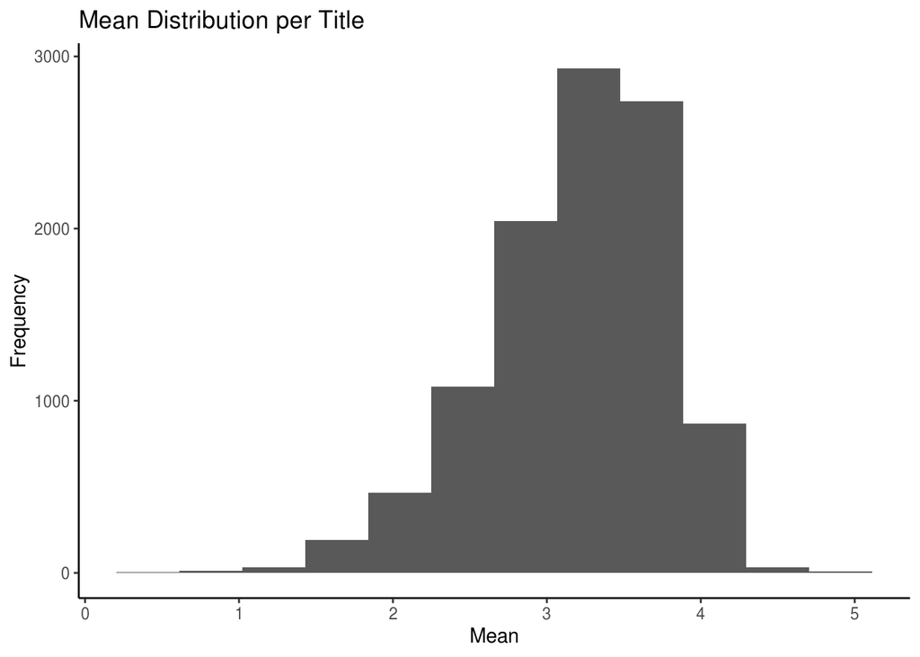

## Methodology and various tools used in the process

### Model based approach

The simplest model is a Naive Model that predict the mean. This model predict the same rating for all movies regardless of user, and that assumes the same rating for all movies and users with all the differences explained by random variation would look like this:

[figure not shown]

[output not shown]

With

[figure not shown]

is the mean and

[figure not shown]

is the independent errors sampled from the same distribution centered at 0.

The RMSE on the `validation` dataset is **1.05**. It is very far for the target RMSE (below 0.87) and that indicates poor performance for the model.

### Predicted ~ Movie Model, based on Movie effect

Nothice that some movies are just generally rated higher than others. This intuition, that different movies are rated differently, is confirmed by data. We can augment our previous model by adding the term

[figure not shown]

to represent average ranking for movie

[figure not shown]

:

[figure not shown]

With

[figure not shown]

is the mean and

[figure not shown]

is the independent errors sampled from the same distribution centered at 0. The

[figure not shown]

is a measure for the popularity of movie

[figure not shown]

, i.e. the bias of movie

[figure not shown]

.

The RMSE on the `validation` dataset is **0.94**. It better than the Naive Mean-Baseline Model, but it is also very far from the target RMSE (below 0.87) and that indicates poor performance for the model.

### Predicted ~ Movie + User Model, based on User

the average rating for user

[figure not shown]

for those that have rated over 100 movies:

[figure not shown]

where

[figure not shown]

is a user-specific effect. Now if a cranky user rates a great movie the effects counter each other and we may be able to correctly predict that this user gave this great movie a 3 rather than a 5.

With

[figure not shown]

is the mean and

[figure not shown]

is the independent errors sampled from the same distribution centered at 0. The

[figure not shown]

is a measure for the popularity of movie

[figure not shown]

, i.e. the bias of movie

[figure not shown]

. The

[figure not shown]

is a measure for the mildness of user

[figure not shown]

, i.e. the bias of user

[figure not shown]

.

The RMSE on the `validation` dataset is **0.8635** and this is very good. The Movie+User Based Model reaches the desidered performance but applying the regularization techniques, can improve the performance just a little.

### Predicted ~ Movie + User + Genre Model, based on Genre

[figure not shown]

With

[figure not shown]

is the mean and

[figure not shown]

is the independent errors sampled from the same distribution centered at 0. The

[figure not shown]

is a measure for the popularity of movie

[figure not shown]

, i.e. the bias of movie

[figure not shown]

. The

[figure not shown]

is a measure for the mildness of user

[figure not shown]

, i.e. the bias of user

[figure not shown]

. The

[figure not shown]

is a measure for how much a user

[figure not shown]

favors the genre

[figure not shown]

.

The RMSE on the `validation` dataset is **0.8634** and this is very good. The Movie+User+Genre Based Model reaches the desidered performance but adding the `genre` predictor, doesn’t improve significantly the model’s performance. Applying the regularization techniques, can improve the performance just a little.

### Regularization

The regularization method allows us to add a penalty

[figure not shown]

[figure not shown]

, it necessary to use this equation:

[figure not shown]

The first term is just least squares and the second is a penalty that gets larger when many

[figure not shown]

are large. Using calculus we can actually show that the values of

[figure not shown]

that minimize this equation are:

[figure not shown]

### Regularized Predicted ~ Movie Model

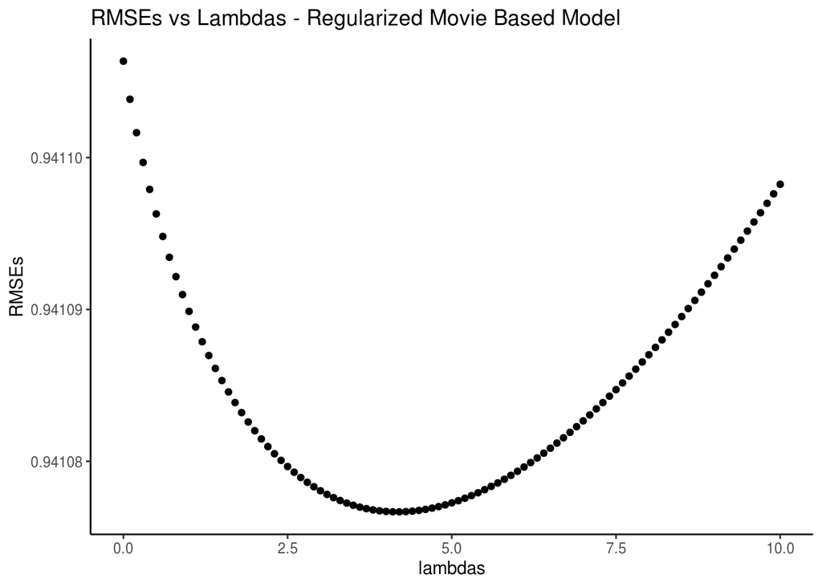

### Regularized Predicted ~ Movie + User Model

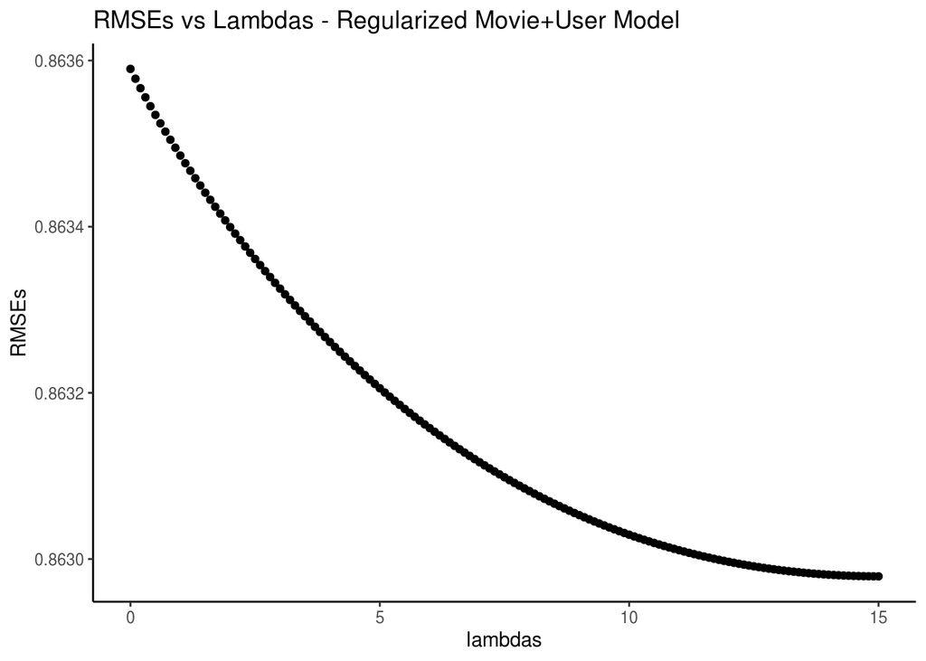

The RMSE on the `validation` dataset is **0.8629**. The Regularized Movie+User Based Model improves just a little the result of the Non-Regularized Model.

### Regularized Predicted ~ Movie + User + Genre Model

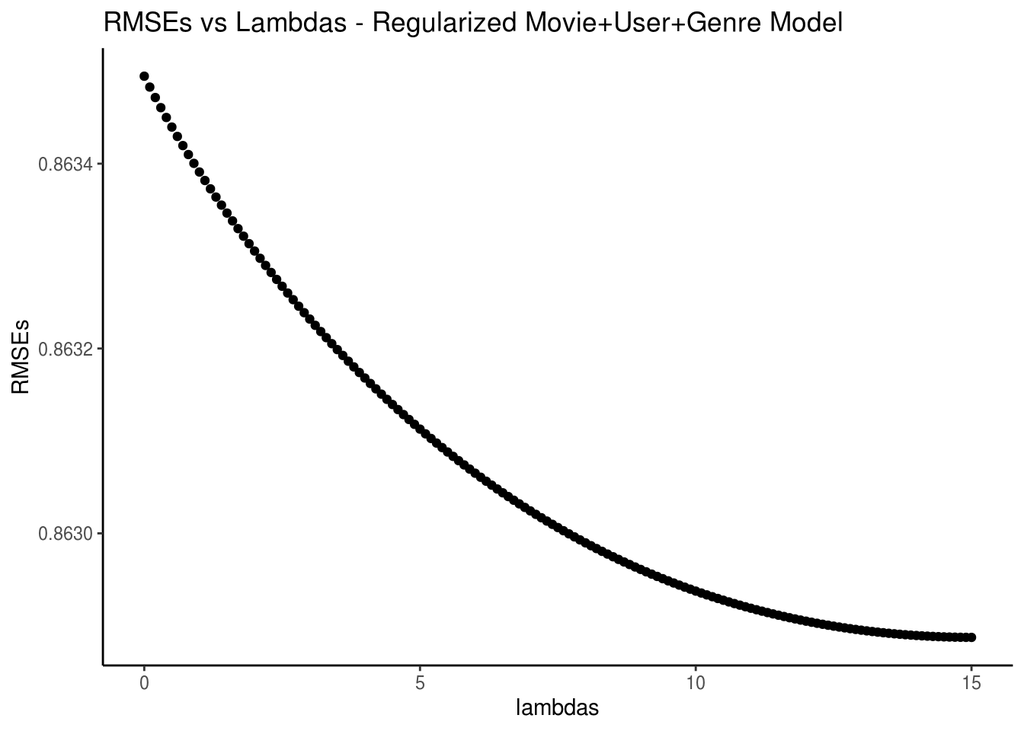

The RMSE on the `validation` dataset is **0.8628** and this is the best result of the builted models. The Regularized Movie+User+Genre Based Model improves just a little the result of the Non-Regularized Model. As the Non-Regularized Model, the `genre` predictor doesn’t improve significantly the model’s performance.

## Reporting

This is the summary results for all the model builted, trained on `edx` dataset and validated on the `validation` dataset.

| model | RMSE |
| --- | --- |
| Naive Mean-Baseline Model | 1.0524433 |
| Movie-Based Model | 0.9411063 |
| Movie+User Based Model | 0.8635899 |
| Movie+User+Genre Based Model | 0.8634946 |
| Regularized Movie-Based Model | 0.9410767 |
| Regularized Movie+User Based Model | 0.8629791 |
| Regularized Movie+User+Genre Based Model | 0.8628874 |

## Recommendations

It’s clear that `movieId` and `userId` contribute more than the `genre` predictor. Without regularization, the model can archieves and overtakes the desidered peformance, but the best is the enemy of the good and applying regularization and adding the `genre` predictor, it make possible to reach a RSME of **0.8628** that is the best result for the trained models.